# Законодательный уровень информационной безопасности

Основы информационной безопасности

Закиров Н. Д.

Российский университет дружбы народов, Москва, Россия

02 Марта 2024

## Докладчик

- Закиров Нурислам Дамирович
- студент группы НКАбд-01-23
- Российский университет дружбы народов

## Основные понятия

1. Информационная безопасность
2. Конфиденциальность
3. Целостность
4. Доступность

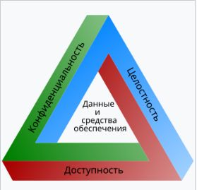

## Конституция РФ

Конституция РФ закрепляет следующие положения:

1. Статья 23 – право граждан на защиту частной жизни;
2. Статья 24 – запрет на сбор и распространение информации без согласия;
3. Статья 29 – свобода информации с ограничениями в целях безопасности.

## Федеральные законы

Важные нормативные акты:

1. 149-ФЗ «Об информации» – регулирует доступ, обработку и защиту данных;
2. 152-ФЗ «О персональных данных» – устанавливает требования к защите ПДн;
3. 187-ФЗ «О КИИ» – определяет меры защиты критической инфраструктуры.

## Примеры нарушений и угроз информационной безопасности.

Рассмотрим несколько реальных примеров киберинцидентов в России:

1. Утечка данных клиентов Сбербанка (2019 год)
2. Взлом серверов российских министерств (2022 год)
3. Атака на систему голосования «Госуслуги» (2023 год)

## ФСТЭК

Выполняет контроль за защитой информации, сертификация средств защиты информации.

[figure not shown]

## ФСБ

Обеспечивает криптографической защиты информации, борьба с кибершпионажем.

[figure not shown]

## Роскомнадзор

Контроль за соблюдением закона о персональных данных (152-ФЗ).

[figure not shown]

## Минцифры

Разрабатывает стратегии и нормативные акты в сфере ИБ.

[figure not shown]

## Проблемы и перспективы развития законодательства в сфере ИБ

1. Стремительное развитие технологий (ИИ, квантовые вычисления);
2. Недостаточная осведомленность бизнеса о требованиях безопасности;
3. Трудности в привлечении к ответственности киберпреступников.

## Заключение

Законодательство РФ в сфере информационной безопасности развивается в ответ на растущие вызовы цифрового мира.

## Представление данных

- Спасибо за внимание!